# Cyclistic Case Study

Furkan Beyazit Yagiz

# First

For this project I’ll be using R to find trends of the dataset Cyclistic in depth. I’m Furkan. Here to explain in my aspect. I will be following the steps of the data analysis process: ask, prepare, process, analyze, share, and act.

## Scenario

A junior data analyst working in the marketing analyst team at Cyclistic, a bike-share company in Chicago(This is originally a case study for my Google data analytics certificate project). What do we know? Cyclistic has a fleet of 5,824 bicycles that are geotracked and locked into a network of 692 stations across Chicago. The bikes can be unlocked from one station and returned to any other station in the system anytime. Until now, Cyclistic’s marketing strategy relied on building general awareness and appealing to broad consumer segments. One approach that helped make these things possible was the flexibility of its pricing plans: single-ride passes, full-day passes, and annual memberships. Customers who purchase single-ride or full-day passes are referred to as casual riders. Customers who purchase annual memberships are Cyclistic members.

Cyclistic’s finance analysts have concluded that annual members are much more profitable than casual riders. Although the pricing flexibility helps Cyclistic attract more customers, the director of marketing Lily Moreno believes that maximizing the number of annual members will be key to future growth. Rather than creating a marketing campaign that targets all-new customers, Moreno believes there is a very good chance to convert casual riders into members. She notes that casual riders are already aware of the Cyclistic program and have chosen Cyclistic for their mobility needs.

## Prepare

I downloaded a year of data which is From April 2020 to March 2021. Here is the Kaggle [link](https://www.kaggle.com/datasets/mihelic/cyclistic) that company provided.

## Process

Even though I’m more comfartable with Python. This time I decided to use R to solve the business problems. I’ll also mention my processing steps.

### Loaded useful libaries

```r
library(tidyverse) # main package of data science
library(janitor) #cleaning
```

```r
library(lubridate) # date
library(RSQLite) # sql
library(ggplot2) # grammar of graphics aka visualizing
#For map and web widgets
library(leaflet)
library(htmlwidgets)
library(htmltools)
#In case if your first time using these packages you have to install first using install.packages("")
```

### the merged our datasets into one data frame

```r
df1<-read.csv("./2020apr.csv")
df2<-read.csv("./2020may.csv")
df3<-read.csv("./2020jun.csv")
df4<-read.csv("./2020jul.csv")
df5<-read.csv("./2020aug.csv")
df6<-read.csv("./2020sep.csv")
df7<-read.csv("./2020oct.csv")
df8<-read.csv("./2020nov.csv")
df9<-read.csv("./2020dec.csv")
df10<-read.csv("./2021jan.csv")
df11<-read.csv("./2021feb.csv")
df12<-read.csv("./2021mar.csv")
bike_rides <- rbind(df1,df2,df3,df4,df5,df6,df7,df8,df9,df10,df11,df12)
```

Getting more info about the data

```r
str(bike_rides)
```

```
## 'data.frame':    3489748 obs. of  13 variables:
##  $ ride_id           : chr  "A847FADBBC638E45" "5405B80E996FF60D" "5DD24A79A4E006F4" "2A59BBDF5CDBA725" ...
##  $ rideable_type     : chr  "docked_bike" "docked_bike" "docked_bike" "docked_bike" ...
##  $ started_at        : chr  "2020-04-26 17:45:14" "2020-04-17 17:08:54" "2020-04-01 17:54:13" "2020-04-07 12:50:19" ...
##  $ ended_at          : chr  "2020-04-26 18:12:03" "2020-04-17 17:17:03" "2020-04-01 18:08:36" "2020-04-07 13:02:31" ...
##  $ start_station_name: chr  "Eckhart Park" "Drake Ave & Fullerton Ave" "McClurg Ct & Erie St" "California Ave & Division St" ...
##  $ start_station_id  : chr  "86" "503" "142" "216" ...
##  $ end_station_name  : chr  "Lincoln Ave & Diversey Pkwy" "Kosciuszko Park" "Indiana Ave & Roosevelt Rd" "Wood St & Augusta Blvd" ...
##  $ end_station_id    : chr  "152" "499" "255" "657" ...
##  $ start_lat         : num  41.9 41.9 41.9 41.9 41.9 ...
##  $ start_lng         : num  -87.7 -87.7 -87.6 -87.7 -87.6 ...
##  $ end_lat           : num  41.9 41.9 41.9 41.9 42 ...
##  $ end_lng           : num  -87.7 -87.7 -87.6 -87.7 -87.7 ...
##  $ member_casual     : chr  "member" "member" "member" "member" ...
```

```r
colnames(bike_rides)
```

```
##  [1] "ride_id"            "rideable_type"      "started_at"
##  [4] "ended_at"           "start_station_name" "start_station_id"
##  [7] "end_station_name"   "end_station_id"     "start_lat"
## [10] "start_lng"          "end_lat"            "end_lng"
## [13] "member_casual"
```

```r
glimpse(bike_rides)
```

```
## Rows: 3,489,748
## Columns: 13
## $ ride_id            <chr> "A847FADBBC638E45", "5405B80E996FF60D", "5DD24A79A4…
## $ rideable_type      <chr> "docked_bike", "docked_bike", "docked_bike", "docke…
## $ started_at         <chr> "2020-04-26 17:45:14", "2020-04-17 17:08:54", "2020…
## $ ended_at           <chr> "2020-04-26 18:12:03", "2020-04-17 17:17:03", "2020…
## $ start_station_name <chr> "Eckhart Park", "Drake Ave & Fullerton Ave", "McClu…
## $ start_station_id   <chr> "86", "503", "142", "216", "125", "173", "35", "434…
## $ end_station_name   <chr> "Lincoln Ave & Diversey Pkwy", "Kosciuszko Park", "…
## $ end_station_id     <chr> "152", "499", "255", "657", "323", "35", "635", "38…
## $ start_lat          <dbl> 41.8964, 41.9244, 41.8945, 41.9030, 41.8902, 41.896…
## $ start_lng          <dbl> -87.6610, -87.7154, -87.6179, -87.6975, -87.6262, -…
## $ end_lat            <dbl> 41.9322, 41.9306, 41.8679, 41.8992, 41.9695, 41.892…
## $ end_lng            <dbl> -87.6586, -87.7238, -87.6230, -87.6722, -87.6547, -…
## $ member_casual      <chr> "member", "member", "member", "member", "casual", "…
```

Removing Duplicates Checking how many rows are deleted

```r
nrow(bike_rides)
```

```
## [1] 3489748
```

```r
bike_rides_nd<- bike_rides[!duplicated(bike_rides$ride_id),]
print(paste("Removed ",nrow(bike_rides)-nrow(bike_rides_nd),'rows'))
```

```
## [1] "Removed  209 rows"
```

As we did see above time columns are characters we have to change them into time and Creating new columns for further time calculations and analysis

```r
bike_rides_nd$started_at<- strptime(bike_rides_nd$started_at,format="%Y-%m-%d %H:%M:%S", tz="America/Chicago")
bike_rides_nd$ended_at<- strptime(bike_rides_nd$ended_at, format="%Y-%m-%d %H:%M:%S", tz="America/Chicago")

# new columns
bike_rides_nd$date<- as.Date(bike_rides_nd$started_at)
bike_rides_nd$month<- format(as.Date(bike_rides_nd$started_at),"%m")
bike_rides_nd$day<- format(as.Date(bike_rides_nd$started_at),"%d")
bike_rides_nd$year<- format(as.Date(bike_rides_nd$started_at),"%Y")
bike_rides_nd$day_of_week<- format(as.Date(bike_rides_nd$started_at),"%A")
```

Finding for how long people were using bikes

```r
bike_rides_nd$ride_length<- difftime(bike_rides_nd$ended_at,bike_rides_nd$started_at)
bike_rides_nd$ride_length<- as.numeric(as.character(bike_rides_nd$ride_length))
str(bike_rides_nd)
```

```
## 'data.frame':    3489539 obs. of  19 variables:
##  $ ride_id           : chr  "A847FADBBC638E45" "5405B80E996FF60D" "5DD24A79A4E006F4" "2A59BBDF5CDBA725" ...
##  $ rideable_type     : chr  "docked_bike" "docked_bike" "docked_bike" "docked_bike" ...
##  $ started_at        : POSIXlt, format: "2020-04-26 17:45:14" "2020-04-17 17:08:54" ...
##  $ ended_at          : POSIXlt, format: "2020-04-26 18:12:03" "2020-04-17 17:17:03" ...
##  $ start_station_name: chr  "Eckhart Park" "Drake Ave & Fullerton Ave" "McClurg Ct & Erie St" "California Ave & Division St" ...
##  $ start_station_id  : chr  "86" "503" "142" "216" ...
##  $ end_station_name  : chr  "Lincoln Ave & Diversey Pkwy" "Kosciuszko Park" "Indiana Ave & Roosevelt Rd" "Wood St & Augusta Blvd" ...
##  $ end_station_id    : chr  "152" "499" "255" "657" ...
##  $ start_lat         : num  41.9 41.9 41.9 41.9 41.9 ...
##  $ start_lng         : num  -87.7 -87.7 -87.6 -87.7 -87.6 ...
##  $ end_lat           : num  41.9 41.9 41.9 41.9 42 ...
##  $ end_lng           : num  -87.7 -87.7 -87.6 -87.7 -87.7 ...
##  $ member_casual     : chr  "member" "member" "member" "member" ...
##  $ date              : Date, format: "2020-04-26" "2020-04-17" ...
##  $ month             : chr  "04" "04" "04" "04" ...
##  $ day               : chr  "26" "17" "01" "07" ...
##  $ year              : chr  "2020" "2020" "2020" "2020" ...
##  $ day_of_week       : chr  "Sunday" "Friday" "Wednesday" "Tuesday" ...
##  $ ride_length       : num  1609 489 863 732 3175 ...
```

```r
##converting ride length into minutes
bike_rides_nd$ride_length_m<-bike_rides_nd$ride_length/60
summary(bike_rides_nd$ride_length_m)
```

```
##      Min.   1st Qu.    Median      Mean   3rd Qu.      Max.
## -29049.97      7.88     14.52     26.48     26.63  58720.03
```

As we have seen above min value is a minus and max value is not correct to solve this we have to remove outliers

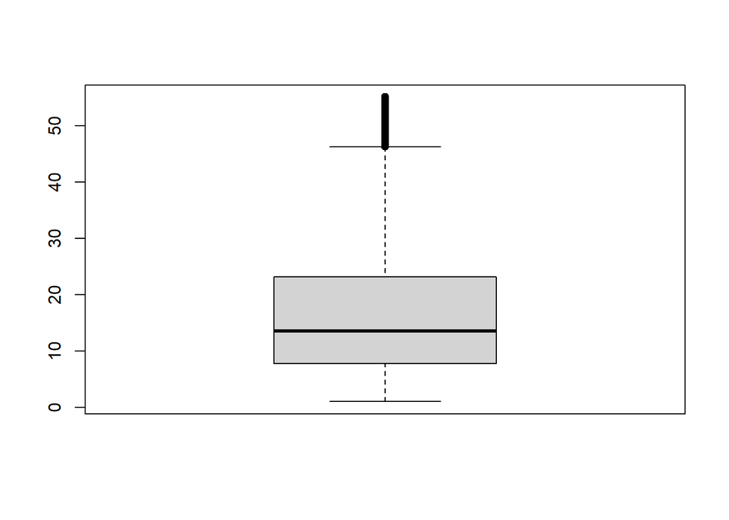

```r
#first removing minus values
bike_rides_nd<-bike_rides_nd %>%
  filter(ride_length_m >= 1)
#now IQR outlier removing method
quartiles<-quantile(bike_rides_nd$ride_length_m,probs=c(.25,.75),na.rm=FALSE)
IQR<-IQR(bike_rides_nd$ride_length_m) ## q3-q1 = IQR
lower<-quartiles[1]-IQR*1.5
upper<-quartiles[2]+IQR*1.5

df<- subset(bike_rides_nd,bike_rides_nd$ride_length_m > lower & bike_rides_nd$ride_length_m < upper)

boxplot(df$ride_length_m)
```

```r
summary(df$ride_length_m)
```

```
##    Min. 1st Qu.  Median    Mean 3rd Qu.    Max.
##    1.00    7.75   13.55   16.75   23.17   55.05
```

Data is still looking very big even if we remove nan values so let’s remove them.

```r
sum(is.na(df))
```

```
## [1] 165893
```

```r
df<-clean_names(df)
df<-remove_empty(df)
```

```
## value for "which" not specified, defaulting to c("rows", "cols")
```

```r
df <- df %>% drop_na()
summary(df)
```

```
##    ride_id          rideable_type        started_at
##  Length:3039021     Length:3039021     Min.   :2020-04-01 00:00:30.00
##  Class :character   Class :character   1st Qu.:2020-07-14 12:50:21.00
##  Mode  :character   Mode  :character   Median :2020-08-29 09:59:44.00
##                                        Mean   :2020-09-10 20:42:08.60
##                                        3rd Qu.:2020-10-22 17:07:24.00
##                                        Max.   :2021-03-31 23:59:08.00
##     ended_at                      start_station_name start_station_id
##  Min.   :2020-04-01 00:10:45.00   Length:3039021     Length:3039021
##  1st Qu.:2020-07-14 13:07:59.00   Class :character   Class :character
##  Median :2020-08-29 10:17:19.00   Mode  :character   Mode  :character
##  Mean   :2020-09-10 20:58:57.30
##  3rd Qu.:2020-10-22 17:23:33.00
##  Max.   :2021-04-01 00:35:27.00
##  end_station_name   end_station_id       start_lat       start_lng
##  Length:3039021     Length:3039021     Min.   :41.65   Min.   :-87.78
##  Class :character   Class :character   1st Qu.:41.88   1st Qu.:-87.66
##  Mode  :character   Mode  :character   Median :41.90   Median :-87.64
##                                        Mean   :41.91   Mean   :-87.65
##                                        3rd Qu.:41.93   3rd Qu.:-87.63
##                                        Max.   :42.07   Max.   :-87.53
##     end_lat         end_lng       member_casual           date
##  Min.   :41.54   Min.   :-87.82   Length:3039021     Min.   :2020-04-01
##  1st Qu.:41.88   1st Qu.:-87.66   Class :character   1st Qu.:2020-07-14
##  Median :41.90   Median :-87.64   Mode  :character   Median :2020-08-29
##  Mean   :41.91   Mean   :-87.65                      Mean   :2020-09-10
##  3rd Qu.:41.93   3rd Qu.:-87.63                      3rd Qu.:2020-10-22
##  Max.   :42.08   Max.   :-87.51                      Max.   :2021-03-31
##     month               day                year           day_of_week
##  Length:3039021     Length:3039021     Length:3039021     Length:3039021
##  Class :character   Class :character   Class :character   Class :character
##  Mode  :character   Mode  :character   Mode  :character   Mode  :character
##
##
##
##   ride_length   ride_length_m
##  Min.   :  60   Min.   : 1.00
##  1st Qu.: 468   1st Qu.: 7.80
##  Median : 818   Median :13.63
##  Mean   :1009   Mean   :16.81
##  3rd Qu.:1395   3rd Qu.:23.25
##  Max.   :3303   Max.   :55.05
```

## Analyze

Member vs Casual Riding times

```r
aggregate(df$ride_length~df$member_casual,FUN=mean)
```

```
##   df$member_casual df$ride_length
## 1           casual      1237.5234
## 2           member       876.0781
```

```r
aggregate(df$ride_length~df$member_casual,FUN=median)
```

```
##   df$member_casual df$ride_length
## 1           casual           1067
## 2           member            695
```

```r
aggregate(df$ride_length~df$member_casual,FUN=max)
```

```
##   df$member_casual df$ride_length
## 1           casual           3303
## 2           member           3303
```

```r
aggregate(df$ride_length~df$member_casual,FUN=min)
```

```
##   df$member_casual df$ride_length
## 1           casual             60
## 2           member             60
```

User Percentage (member vs casual)

```r
df %>%
  group_by(member_casual) %>%
  summarise(count=length(ride_id),"percentage"=(length(ride_id)/nrow(df))*100)
```

```
## # A tibble: 2 × 3
##   member_casual   count percentage
##   <chr>           <int>      <dbl>
## 1 casual        1115112       36.7
## 2 member        1923909       63.3
```

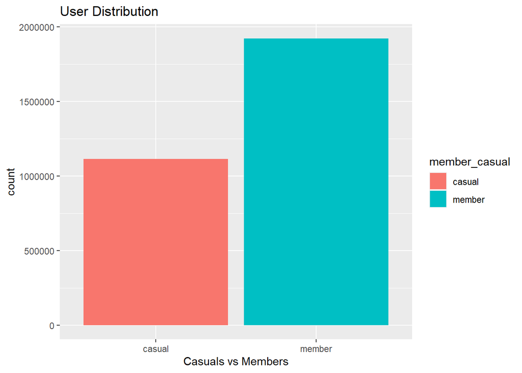

```r
ggplot(df,aes(member_casual,fill=member_casual))+
  geom_bar()+
  labs(x="Casuals vs Members",title = "User Distribution")
```

Average ride time(minutes) by day for members vs casual

```r
df$day_of_week<-ordered(df$day_of_week, levels=c("Monday","Tuesday", "Wednesday", "Thursday", "Friday", "Saturday","Sunday"))
aggregate(df$ride_length_m~df$member_casual+df$day_of_week,FUN=mean)
```

```
##    df$member_casual df$day_of_week df$ride_length_m
## 1            casual         Monday         20.35895
## 2            member         Monday         14.00390
## 3            casual        Tuesday         19.63048
## 4            member        Tuesday         13.92639
## 5            casual      Wednesday         19.31239
## 6            member      Wednesday         13.97046
## 7            casual       Thursday         19.35819
## 8            member       Thursday         13.99818
## 9            casual         Friday         20.01049
## 10           member         Friday         14.28247
## 11           casual       Saturday         21.77508
## 12           member       Saturday         15.96641
## 13           casual         Sunday         22.10199
## 14           member         Sunday         16.07994
```

More

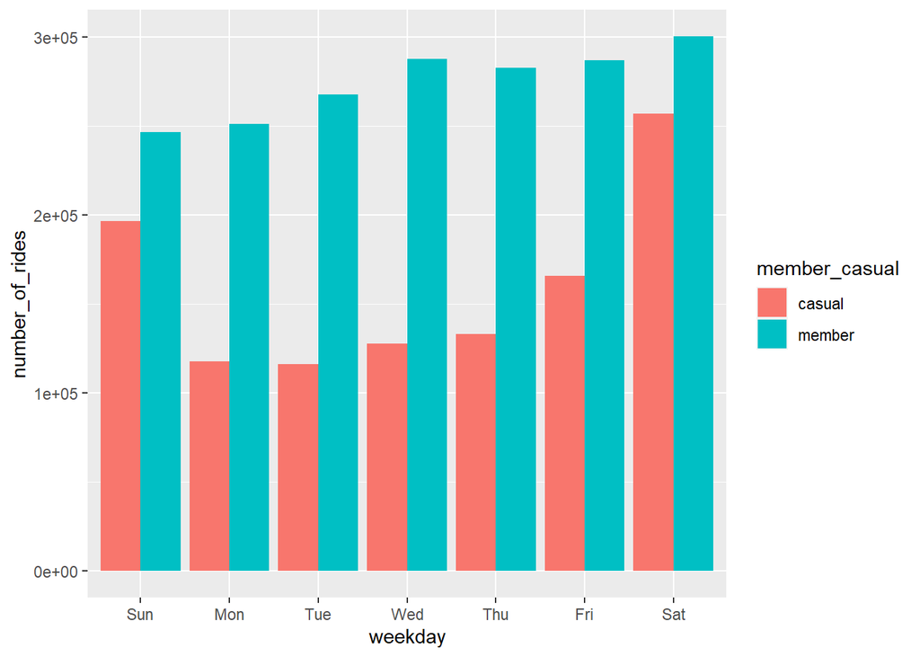

```r
## Number of rides by Day member vs casual

df %>%
  mutate(weekday=wday(started_at,label=TRUE)) %>%
  group_by(member_casual,weekday) %>%
  summarise(number_of_rides=n(),average_duration=mean(ride_length_m)) %>%
  arrange(member_casual,weekday) %>%
  ggplot(aes(x=weekday,y=number_of_rides,fill=member_casual))+
  geom_col(position='dodge')
```

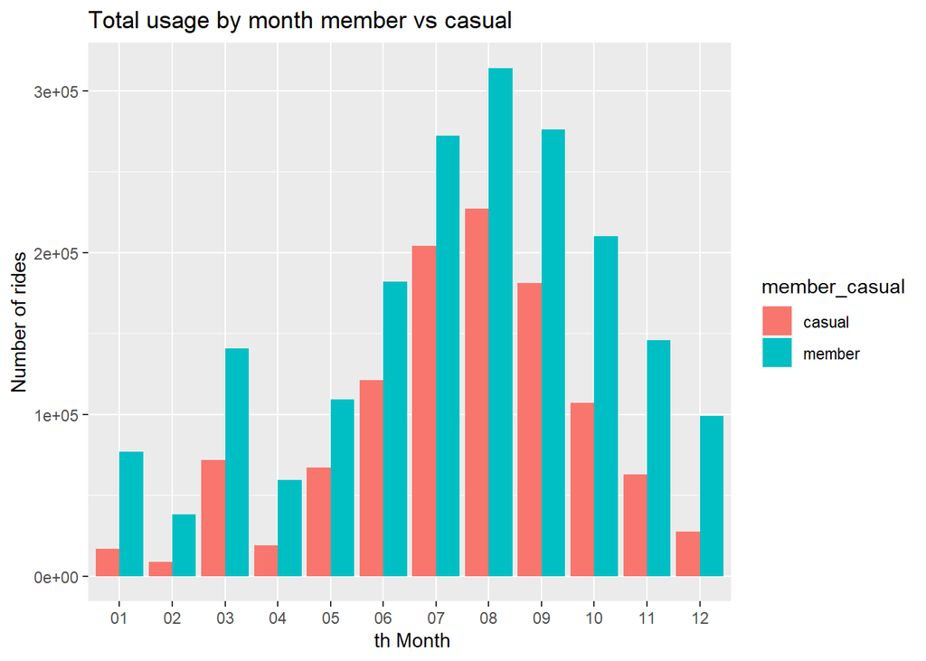

```r
## Usage by Month

df %>%
  group_by(member_casual,month) %>%
  summarise(number_of_rides=n(),average_duration=mean(ride_length_m)) %>%
  arrange(member_casual,month) %>%
  ggplot(aes(x=month,y=number_of_rides,fill=member_casual))+
  geom_col(position='dodge')+labs(title='Total usage by month member vs casual',x=" th Month",y="Number of rides")
```

```r
## bike type usage members vs casual
df %>%
  group_by(rideable_type,member_casual) %>%
  summarize(mean_min=mean(ride_length_m))
```

```
## # A tibble: 6 × 3
## # Groups:   rideable_type [3]
##   rideable_type member_casual mean_min
##   <chr>         <chr>            <dbl>
## 1 classic_bike  casual            18.2
## 2 classic_bike  member            12.8
## 3 docked_bike   casual            21.6
## 4 docked_bike   member            15.4
## 5 electric_bike casual            16.3
## 6 electric_bike member            12.3
```

```r
dftype<- df %>%
  group_by(rideable_type,member_casual) %>%
  summarize(mean_min=mean(ride_length_m))
```

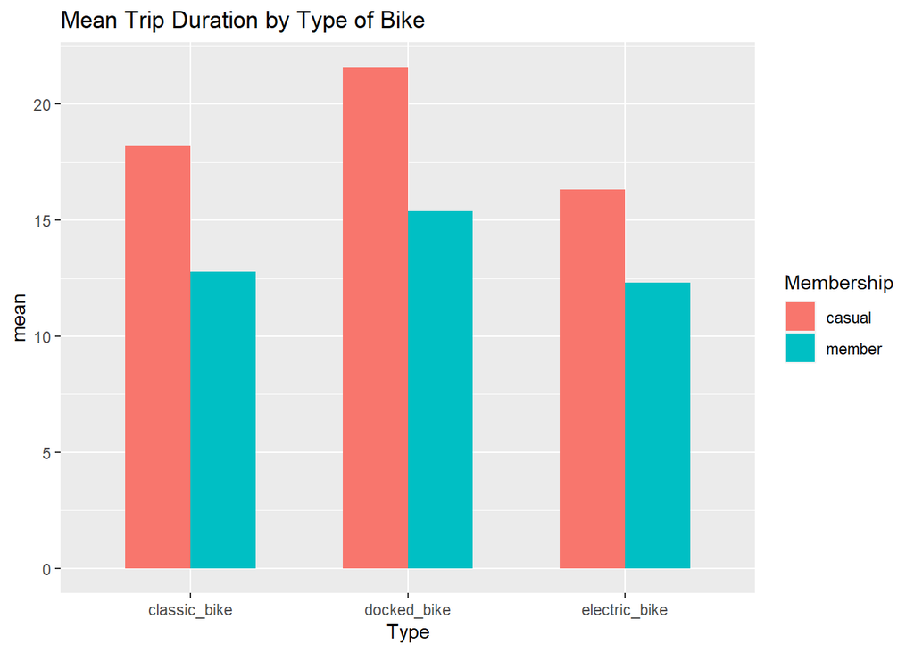

```r
dftype %>%
  ggplot(aes(x=rideable_type,y=mean_min,fill=member_casual))+
  geom_col(position = position_dodge(),width = 0.6)+
  labs(x='Type',y="mean",fill='Membership')+
  ggtitle("Mean Trip Duration by Type of Bike")
```

```r
## Total usage in Specific hours member vs casual
df$hour <- format(df$started_at, "%H")
table(df$hour,df$member_casual)
```

```
##
##      casual member
##   00  16393  10936
##   01  10202   6069
##   02   5625   3253
##   03   3024   2045
##   04   2727   3270
##   05   4364  16429
##   06  11040  54031
##   07  20142  90499
##   08  26897  97653
##   09  32378  81984
##   10  44517  86590
##   11  61490 108270
##   12  74977 127367
##   13  80902 126561
##   14  85380 126414
##   15  91481 140765
##   16  99295 169148
##   17 112940 202889
##   18 101734 176025
##   19  76987 122269
##   20  53841  74638
##   21  38126  44508
##   22  33658  31195
##   23  26992  21101
```

```r
dftod<- df %>%
  group_by(hour,member_casual) %>%
  summarize(n=n()) %>%
  mutate_if(is.numeric,round,2) %>%
  print(n=nrow(24))
```

[output not shown]

```
## # A tibble: 48 × 3
## # Groups:   hour [24]
##    hour  member_casual     n
##    <chr> <chr>         <dbl>
##  1 00    casual        16393
##  2 00    member        10936
##  3 01    casual        10202
##  4 01    member         6069
##  5 02    casual         5625
##  6 02    member         3253
##  7 03    casual         3024
##  8 03    member         2045
##  9 04    casual         2727
## 10 04    member         3270
## # ℹ 38 more rows
```

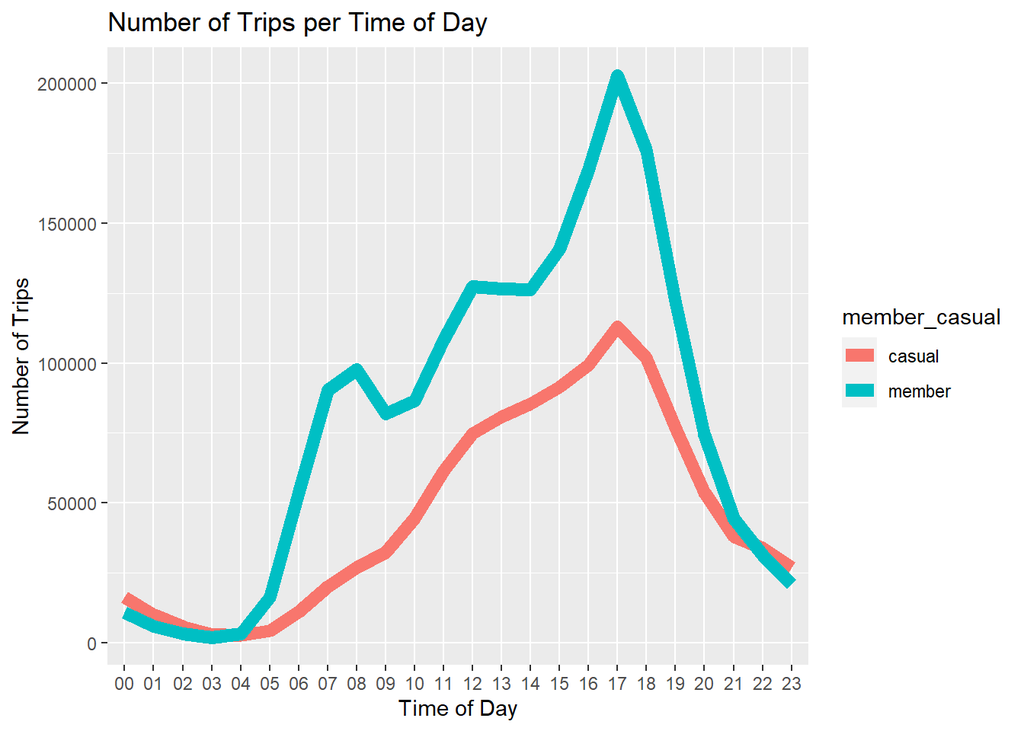

```r
dftod %>%
  ggplot()+
  geom_line(aes(x=hour,y=n,color=member_casual,group=member_casual),size=3)+
  labs(x = "Time of Day", y = "Number of Trips", fill = "Membership Type") +
  ggtitle("Number of Trips per Time of Day")
```

Cool Looking Station Map View Analysis

```r
## Stations Map view

dfmap<-df %>%
  group_by(start_station_name) %>%
  summarize(n=n())
  dfmap[order(dfmap$n,decreasing = TRUE),]
```

```
## # A tibble: 705 × 2
##    start_station_name               n
##    <chr>                        <int>
##  1 ""                           37008
##  2 "Clark St & Elm St"          30125
##  3 "Streeter Dr & Grand Ave"    27774
##  4 "Theater on the Lake"        26382
##  5 "Lake Shore Dr & Monroe St"  23634
##  6 "Wells St & Concord Ln"      23556
##  7 "Lake Shore Dr & North Blvd" 23553
##  8 "Broadway & Barry Ave"       22393
##  9 "Dearborn St & Erie St"      21905
## 10 "Wells St & Elm St"          21855
## # ℹ 695 more rows
```

```r
## created Dataframe with coordinates
dfcoor<- df %>%
  select(start_station_name,start_lat,start_lng) %>%
  group_by(start_station_name) %>%
  mutate(num_trips=n()) %>%
  distinct(start_station_name,.keep_all = TRUE)

dfcoor<- dfcoor[order(-dfcoor$num_trips),]

map_bins <- seq(0, 50000, by = 5000)

my_palette <- colorBin(palette ="viridis", domain = dfcoor$num_trips, na.color = "transparent", bins = map_bins, reverse = TRUE)


# set text for interactive
map_text <- paste("Station name: ", dfcoor$start_station_name, "<br/>","Number of trips: ", dfcoor$num_trips, sep = "") %>%
  lapply(htmltools::HTML)


# widget
trips_per<-leaflet(dfcoor) %>%
  addTiles() %>%
#set Chicago coordinates
setView(lng=-87.6298,lat=41.8781,zoom=10.5) %>%

#set map style
addProviderTiles("Esri.WorldGrayCanvas") %>%


#add Circles for each station
  addCircleMarkers(~start_lng,~start_lat,fillColor = ~my_palette(num_trips),fillOpacity = 0.6,color='white',radius=6,stroke=FALSE,label = map_text,labelOptions = labelOptions(style = list("font-weight"="normal",padding="3px 8px"),textsize = "13px",direction = "auto")) %>%

#add legend.
  addLegend(
    pal = my_palette,
    values = ~ num_trips,
    opacity = 0.8,
    title = "Number of Trips",
    position = "bottomright")

#view map.
trips_per
```

[interactive chart not shown]

## Share

- In order to visualize my findings about the dataset I used ggplot to visualize them
- Understood casual bike riders and members preferences
- Map is also will help me show locations at ease